# Biowulf Usage Report

May 18, 2015

## Biowulf Utilization

## Storage Growth

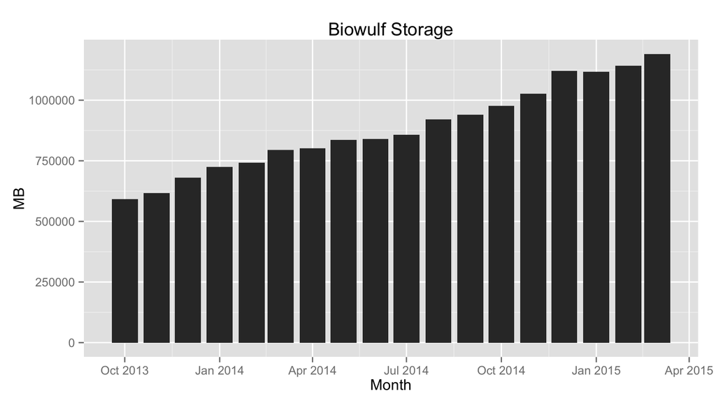

## Storage by PI

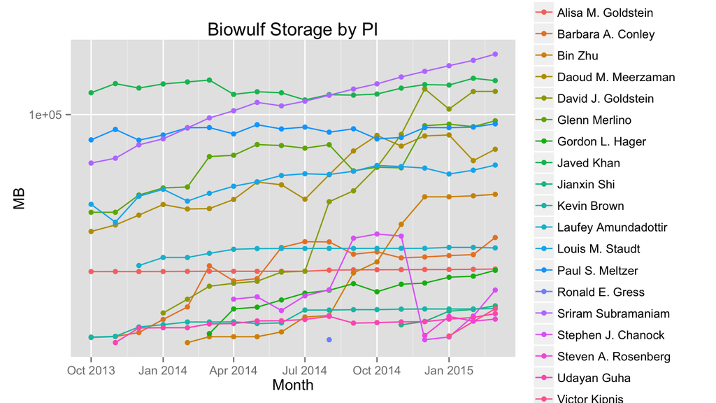

## Compute Usage

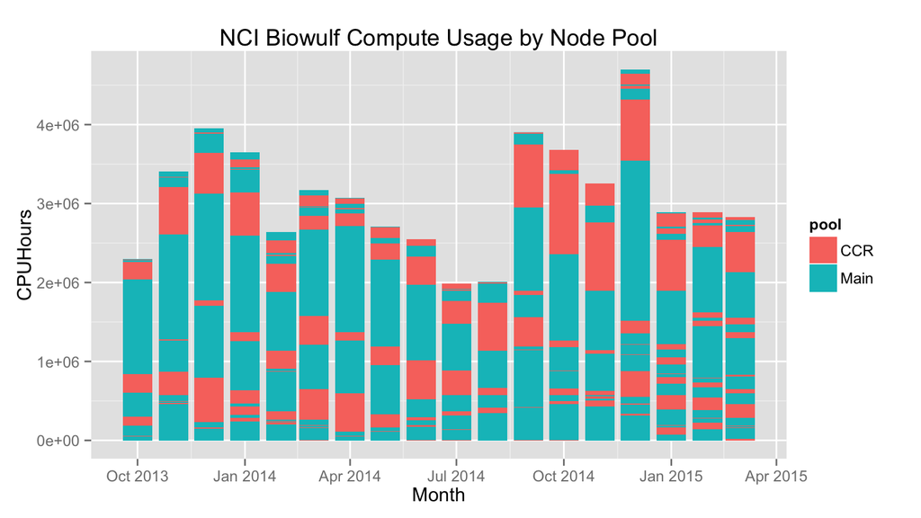

## Compute Usage, CCR nodes only

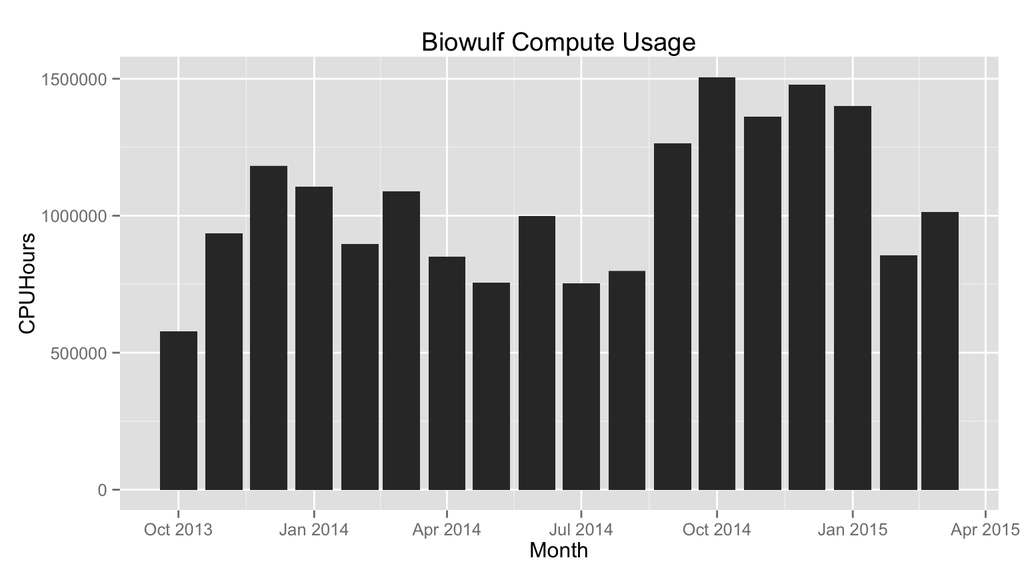

## Compute Usage by PI

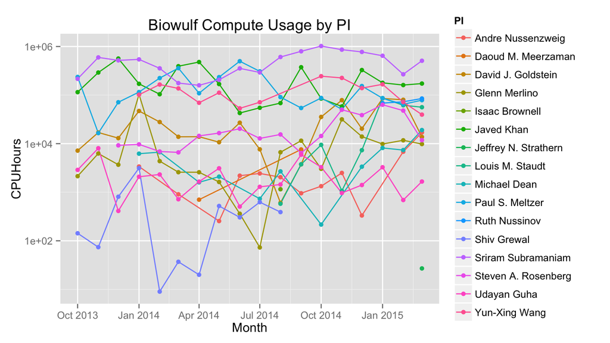

## Compute Usage by PI

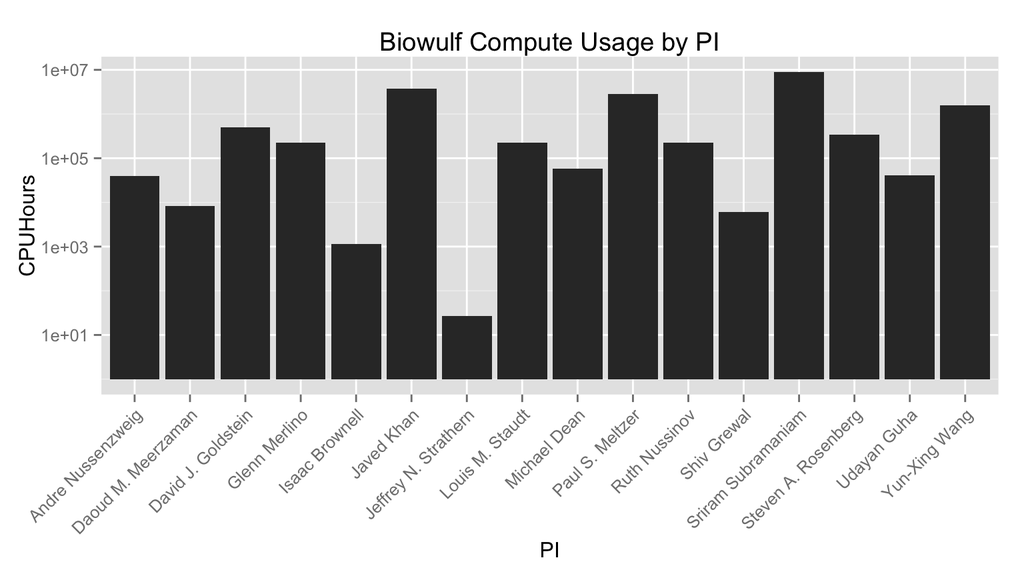

## Compute Usage Trend by PI

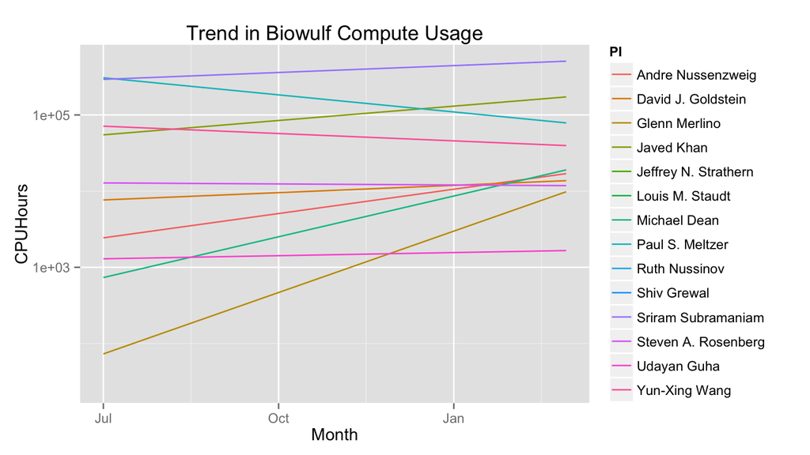

## Biowulf Expansion

## High-level Expansion Plans

- NIH Network implementation (in progress)
- Remodel data center to allow expansion (complete)
- New network implementation in the data center (nearly complete)
- Biowulf2 hardware installation, phase I (complete)
- Software testing and batch system redesign (nearly complete)

## By the Numbers

| Year | Storage (PB) | Cores | CCR Nodes | CCR Storage (PB) |
| --- | --- | --- | --- | --- |
| 2014 | 2.9 | 18494 | 7000 | 0.0 |
| 2015 | 3.9 | 23445 | 10000 | 1.2 |
| 2016 | 6.9 | 53445 | 6000 | 1.2 |
| 2017 | 9.9 | 83445 | 3000 | 1.7 |
| 2018 | 12.9 | 96000 | 3000 | 2.2 |

CCR nodes assume 3-year "lease" business model

- CCR helix node for educational use and interactive work

## Near Term Plan

- Ongoing software installation and testing
- May 27: Beta testers meeting and access available
- July: Open to general users
- New website created–live in July
- Transition older nodes (Summer)
- Transition GPFS storage system (Summer)
- Add Cleversafe storage system (Summer)
- Transfer nodes available (partially complete)

## User Transition

- Lipsett announcement planned prior to going live
- Three training sessions planned
- NCI training and communication

## So What?

- New batch system will mean more efficient use of resources
- New network internally means faster genomics processing (marginal)
- New NIH network brings possibilities for data management not currently possible
- More nodes means shorter wait times and more computing cycles
- Larger, more capable nodes designed to be dual-purpose
  - Genomics
  - Molecular dynamics
- Strategic plan includes hiring new talent–first already on board

## Other Projects

## Other Projects

- NCI Cloud pilots (CBIIT, CCR/DCEG, Bioconductor)
- NCI Genomic Data Commons (OCG)
- NCI Linux Desktop pilot (CBIIT, NCI)
- CCR Data Lake (CBIIT, CCR, ?CIT)
- Data Science Trainig and Education (ADDS, NIH Library, NCBI)
  - Hackathon, August 2015 (NCBI)
  - MOOC, Fall 2015 (NCBI)
  - Software Carpentry (ADDS)
  - Training and Education Calendar (ADDS, NCBI, NIH Library)

## Other Projects (cont.)

- Cloud Services
  - Amazon Web Services (Leidos, CBIIT)
  - Google Genomics (Bioconductor)
  - Microsoft Azure (CBIIT)
- CBIIT Strategic Planning (CBIIT, Bioteam)
- Genomic Data Sharing Policy Implementation (CCR, DCEG, extramural NCI, NIH OD)